# I2 - integrated land crop model - mapping yield in single terrain

Andreas Angourakis

26 March, 2021

## General preparation

```r
require(colorspace)
```

Load crop table (assumed to always have the same name):

```r
cropTable <- read.csv("yield/I2_yield-exp_cropTable.csv")
```

Reorder crops for a more logical display:

WARNING: doing this manually makes the script sensitive to the value of crop-selection in NetLogo. Thus, this chunk must be uptdated if crop-selection is changed before running experiments.

```r
cropTable$crop <- factor(cropTable$crop, levels = c("proso millet", "pearl millet", "rice", "barley", "wheat 1", "wheat 2"))
```

## Terrain example 1: no river

### Experiment definition

First set any parameters to be used as identifiers of the experiment batches to retrieved:

```r
terrainRandomSeed = 0
```

### Load data

Load the terrain data in the “yield” folder:

```r
terrainData <- read.csv(paste0("yield/I2_yield-exp_terrainRandomSeed=", terrainRandomSeed, ".csv"))
```

Load all experiment output files in the “yield” folder, generated with this version (I2):

```r
file_names <- paste0("yield/", list.files("yield"))

nameFilter <- grepl(paste0("I2_yield-exp_terrainRandomSeed=", terrainRandomSeed, "_"), file_names)

yieldData <- do.call(rbind, lapply(file_names[nameFilter], read.csv))
```

Force the same order of crops used by cropTable:

```r
yieldData$crop <- factor(yieldData$crop, levels = levels(cropTable$crop))
```

### Preparations

Get vector of colours to represent crops:

```r
cropColours <- rainbow(nlevels(cropTable$crop), s = 0.8, v = 0.8, end = 0.85)
```

extract map dimensions:

```r
minX = min(terrainData$x)
maxX = max(terrainData$x)
mapWidth = maxX - minX + 1

minY = min(terrainData$y)
maxY = max(terrainData$y)
mapHeight = maxY - minY + 1
```

### mean ARID and mean ARID in growth season per crop

Build spatial yield matrices:

```r
meanARID_byPos <- matrix(rep(NA, mapWidth * mapHeight), nrow = mapHeight, ncol = mapWidth)

for (i in minX:maxX)
{
  for (j in minY:maxY)
  {
    meanARID_byPos[j+1, i+1] <- mean(yieldData$p_soil_meanARID[yieldData$x == i & yieldData$y == j], na.rm = TRUE)
  }
}

meanARID_grow_byPosAndCrop <- list()

for (aCrop in levels(cropTable$crop))
{
  meanARID_grow_byPosAndCrop[[aCrop]] <- matrix(rep(NA, mapWidth * mapHeight), nrow = mapHeight, ncol = mapWidth)

  for (i in minX:maxX)
  {
    for (j in minY:maxY)
    {
      meanARID_grow_byPosAndCrop[[aCrop]][j+1, i+1] <-
        mean(yieldData$p_soil_meanARID_grow[yieldData$crop == aCrop & yieldData$x == i & yieldData$y == j], na.rm = TRUE)
    }
  }
}
```

```r
plotName = paste0("plots/I2/meanARIDRaster_byCrop_terrainRandomSeed=", terrainRandomSeed,".png")

grScale = 2

png(plotName, width = grScale * 200 * nlevels(cropTable$crop), height = grScale * 800)

layout(matrix(c(rep(nlevels(cropTable$crop) + 2, nlevels(cropTable$crop) + 1), 1:(nlevels(cropTable$crop) + 1)), nrow = 2, byrow = TRUE),
       heights = c(3, 1))

par(cex.main = 1.5 * grScale, cex.axis = 0.6 * grScale)

for (aCrop in levels(cropTable$crop))
{
  colgrp <- findInterval(c(meanARID_grow_byPosAndCrop[[aCrop]]),
                         seq(min(c(meanARID_grow_byPosAndCrop[[aCrop]])),
                             max(c(meanARID_grow_byPosAndCrop[[aCrop]])),
                             length.out = 10))
  colfunc <- colorRampPalette(c(lighten(cropColours[match(aCrop, levels(cropTable$crop))], amount = 0.9),
                                cropColours[match(aCrop, levels(cropTable$crop))]))
  collist <- colfunc(length(unique(colgrp)))

  image(meanARID_grow_byPosAndCrop[[aCrop]],
        col = collist,
        axes = FALSE, xaxt = 'n', yaxt = 'n', ann = FALSE)

  title(main = aCrop)

  axis(2, at = seq(0, 1, length.out = mapHeight), labels = minY:maxY)
  axis(1, at = seq(0, 1, length.out = mapWidth), labels = minX:maxX)
}

image(meanARID_byPos, axes = FALSE, xaxt = 'n', yaxt = 'n', ann = FALSE)

title(main = "entire year")

axis(2, at = seq(0, 1, length.out = mapHeight), labels = minY:maxY)
axis(1, at = seq(0, 1, length.out = mapWidth), labels = minX:maxX)

par(mar = c(5, 20, 5, 5), cex.axis = 2 * grScale, cex.lab = 2 * grScale)

boxplot(p_soil_meanARID_grow ~ factor(crop), data = yieldData,#[yieldData$yield > 0,], # show only non-zero yield
        ylab = "", xlab = "",
        las = 2, xaxt = 'n', cex = grScale,
        col = cropColours)

mtext("mean ARID (growth season)", side = 2, line = 10, cex = 2 * grScale)

dev.off()
```

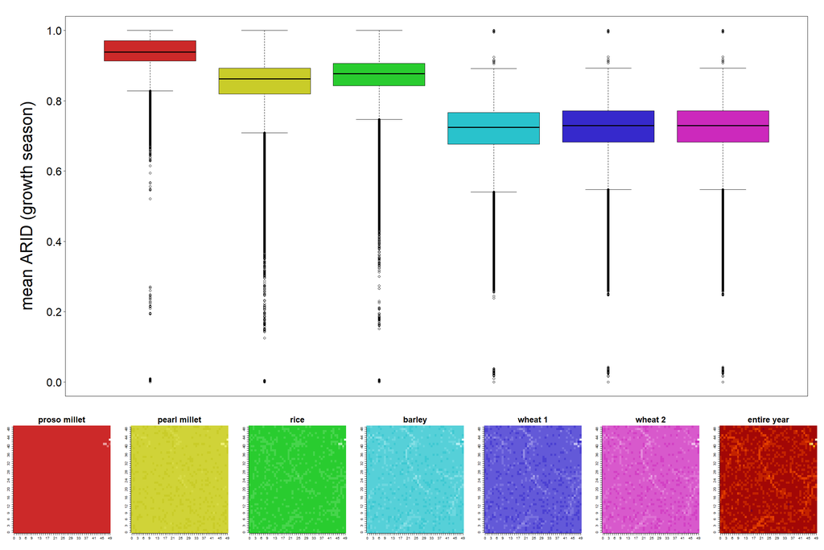

```r
knitr::include_graphics(plotName)
```

### Mean yield per crop

Build spatial yield matrices:

```r
meanYield_byPosAndCrop <- list()

for (aCrop in levels(cropTable$crop))
{
  meanYield_byPosAndCrop[[aCrop]] <- matrix(rep(NA, mapWidth * mapHeight), nrow = mapHeight, ncol = mapWidth)

  for (i in minX:maxX)
  {
    for (j in minY:maxY)
    {
      meanYield_byPosAndCrop[[aCrop]][j+1, i+1] <- mean(yieldData$yield[yieldData$crop == aCrop & yieldData$x == i & yieldData$y == j])
    }
  }
}
```

Plot mean yield per crop in grid map:

```r
plotName = paste0("plots/I2/meanYieldRaster_byCrop_terrainRandomSeed=", terrainRandomSeed,".png")

grScale = 2

png(plotName, width = grScale * 200 * nlevels(cropTable$crop), height = grScale * 800)

layout(matrix(c(rep(nlevels(cropTable$crop) + 1, nlevels(cropTable$crop)), 1:(nlevels(cropTable$crop))), nrow = 2, byrow = TRUE),
       heights = c(3, 1))

par(cex.main = 1.5 * grScale, cex.axis = 0.6 * grScale)

for (aCrop in levels(cropTable$crop))
{
  colgrp <- findInterval(c(meanYield_byPosAndCrop[[aCrop]]),
                         seq(min(c(meanYield_byPosAndCrop[[aCrop]])),
                             max(c(meanYield_byPosAndCrop[[aCrop]])),
                             length.out = 10))
  colfunc <- colorRampPalette(c(lighten(cropColours[match(aCrop, levels(cropTable$crop))], amount = 0.9),
                                cropColours[match(aCrop, levels(cropTable$crop))]))
  collist <- colfunc(length(unique(colgrp)))

  image(meanYield_byPosAndCrop[[aCrop]],
        col = collist,
        axes = FALSE, xaxt = 'n', yaxt = 'n', ann = FALSE)

  title(main = aCrop)

  axis(2, at = seq(0, 1, length.out = mapHeight), labels = minY:maxY)
  axis(1, at = seq(0, 1, length.out = mapWidth), labels = minX:maxX)
}

par(mar = c(5, 20, 5, 5), cex.axis = 2 * grScale, cex.lab = 2 * grScale)

boxplot(yield ~ factor(crop), data = yieldData,#[yieldData$yield > 0,], # show only non-zero yield
        ylab = "", xlab = "",
        las = 2, xaxt = 'n', cex = grScale,
        col = cropColours)

mtext(expression(paste("yield (", g/m^2, ")")), side = 2, line = 10, cex = 2 * grScale)

dev.off()
```

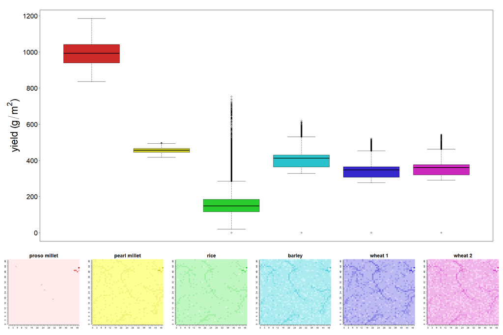

```r
knitr::include_graphics(plotName)
```

Alternative using `heatmap`: NOTE: this function is incompatible with `layout` so plots must be generated separately; it is also hard to customise because of many inaccessible defaults which are set for biostatistics (i.e. genetic data, with lateral dendrograms)).

```r
for (aCrop in levels(cropTable$crop))
{
  plotName = paste0("plots/I2/meanYieldRaster_terrainRandomSeed=", terrainRandomSeed,"_", aCrop, ".png")

  grScale = 2

  png(plotName, width = grScale * 500, height = grScale * 300)

  par(mar = c(3,1,10,1), cex.main = grScale)
  heatmap(meanYield_byPosAndCrop[[aCrop]],
        Rowv = NA, Colv = NA,
        main = aCrop,
        labRow = minY:maxY, labCol = minX:maxX,
        cexRow = 0.8 * grScale, cexCol = 0.8 * grScale)

  dev.off()
}
```

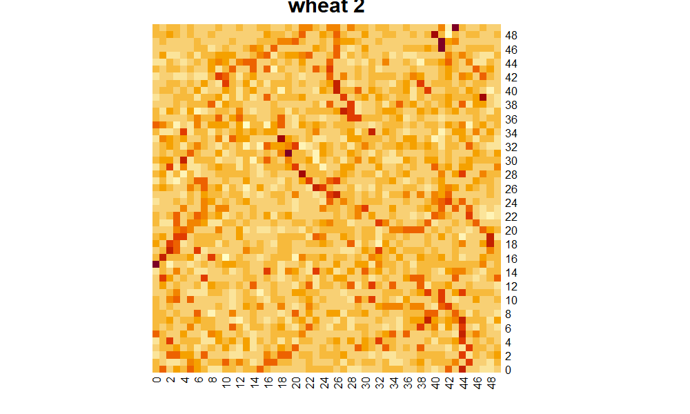

```r
knitr::include_graphics(plotName)
```

## Terrain example 2: river

Clear memory space used by large objects in the R environment:

```r
rm(terrainData, yieldData)
```

### Experiment definition

First set any parameters to be used as identifiers of the experiment batches to retrieved:

```r
terrainRandomSeed = 35
```

### Load data

Load the terrain data in the “yield” folder:

```r
terrainData <- read.csv(paste0("yield/I2_yield-exp_terrainRandomSeed=", terrainRandomSeed, ".csv"))
```

Load all experiment output files in the “yield” folder, generated with this version (I2):

```r
file_names <- paste0("yield/", list.files("yield"))

isThisVersion <- grepl(paste0("I2_yield-exp_terrainRandomSeed=", terrainRandomSeed, "_"), file_names)

yieldData <- do.call(rbind, lapply(file_names[isThisVersion], read.csv))
```

Force the same order of crops used by cropTable:

```r
yieldData$crop <- factor(yieldData$crop, levels = levels(cropTable$crop))
```

### Preparations

Get vector of colours to represent crops:

```r
cropColours <- rainbow(nlevels(cropTable$crop), s = 0.8, v = 0.8, end = 0.85)
```

extract map dimensions:

```r
minX = min(terrainData$x)
maxX = max(terrainData$x)
mapWidth = maxX - minX + 1

minY = min(terrainData$y)
maxY = max(terrainData$y)
mapHeight = maxY - minY + 1
```

### mean ARID and mean ARID in growth season per crop

Build spatial yield matrices:

```r
meanARID_byPos <- matrix(rep(NA, mapWidth * mapHeight), nrow = mapHeight, ncol = mapWidth)

for (i in minX:maxX)
{
  for (j in minY:maxY)
  {
    meanARID_byPos[j+1, i+1] <- mean(yieldData$p_soil_meanARID[yieldData$x == i & yieldData$y == j], na.rm = TRUE)
  }
}

meanARID_grow_byPosAndCrop <- list()

for (aCrop in levels(cropTable$crop))
{
  meanARID_grow_byPosAndCrop[[aCrop]] <- matrix(rep(NA, mapWidth * mapHeight), nrow = mapHeight, ncol = mapWidth)

  for (i in minX:maxX)
  {
    for (j in minY:maxY)
    {
      meanARID_grow_byPosAndCrop[[aCrop]][j+1, i+1] <-
        mean(yieldData$p_soil_meanARID_grow[yieldData$crop == aCrop & yieldData$x == i & yieldData$y == j], na.rm = TRUE)
    }
  }
}
```

```r
plotName = paste0("plots/I2/meanARIDRaster_byCrop_terrainRandomSeed=", terrainRandomSeed,".png")

grScale = 2

png(plotName, width = grScale * 200 * nlevels(cropTable$crop), height = grScale * 800)

layout(matrix(c(rep(nlevels(cropTable$crop) + 2, nlevels(cropTable$crop) + 1), 1:(nlevels(cropTable$crop) + 1)), nrow = 2, byrow = TRUE),
       heights = c(3, 1))

par(cex.main = 1.5 * grScale, cex.axis = 0.6 * grScale)

for (aCrop in levels(cropTable$crop))
{
  colgrp <- findInterval(c(meanARID_grow_byPosAndCrop[[aCrop]]),
                         seq(min(c(meanARID_grow_byPosAndCrop[[aCrop]])),
                             max(c(meanARID_grow_byPosAndCrop[[aCrop]])),
                             length.out = 10))
  colfunc <- colorRampPalette(c(lighten(cropColours[match(aCrop, levels(cropTable$crop))], amount = 0.9),
                                cropColours[match(aCrop, levels(cropTable$crop))]))
  collist <- colfunc(length(unique(colgrp)))

  image(meanARID_grow_byPosAndCrop[[aCrop]],
        col = collist,
        axes = FALSE, xaxt = 'n', yaxt = 'n', ann = FALSE)

  title(main = aCrop)

  axis(2, at = seq(0, 1, length.out = mapHeight), labels = minY:maxY)
  axis(1, at = seq(0, 1, length.out = mapWidth), labels = minX:maxX)
}

image(meanARID_byPos, axes = FALSE, xaxt = 'n', yaxt = 'n', ann = FALSE)

title(main = "entire year")

axis(2, at = seq(0, 1, length.out = mapHeight), labels = minY:maxY)
axis(1, at = seq(0, 1, length.out = mapWidth), labels = minX:maxX)

par(mar = c(5, 20, 5, 5), cex.axis = 2 * grScale, cex.lab = 2 * grScale)

boxplot(p_soil_meanARID_grow ~ factor(crop), data = yieldData,#[yieldData$yield > 0,], # show only non-zero yield
        ylab = "", xlab = "",
        las = 2, xaxt = 'n', cex = grScale,
        col = cropColours)

mtext("mean ARID (growth season)", side = 2, line = 10, cex = 2 * grScale)

dev.off()
```

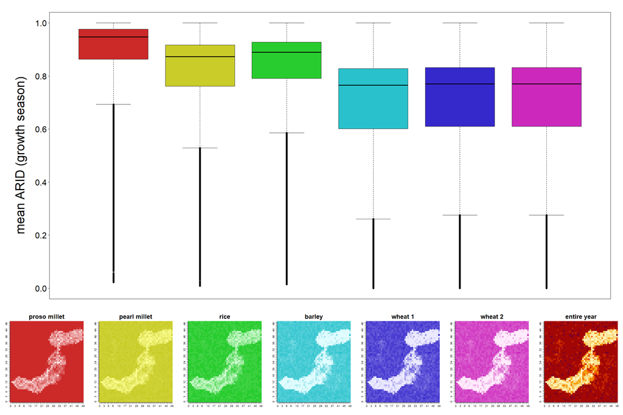

```r
knitr::include_graphics(plotName)
```

### Mean yield per crop

Build spatial yield matrices:

```r
meanYield_byPosAndCrop <- list()

for (aCrop in levels(cropTable$crop))
{
  meanYield_byPosAndCrop[[aCrop]] <- matrix(rep(NA, mapWidth * mapHeight), nrow = mapHeight, ncol = mapWidth)

  for (i in minX:maxX)
  {
    for (j in minY:maxY)
    {
      meanYield_byPosAndCrop[[aCrop]][j+1, i+1] <- mean(yieldData$yield[yieldData$crop == aCrop & yieldData$x == i & yieldData$y == j])
    }
  }
}
```

Plot mean yield per crop in grid map:

```r
plotName = paste0("plots/I2/meanYieldRaster_byCrop_terrainRandomSeed=", terrainRandomSeed,".png")

grScale = 2

png(plotName, width = grScale * 200 * nlevels(cropTable$crop), height = grScale * 800)

layout(matrix(c(rep(nlevels(cropTable$crop) + 1, nlevels(cropTable$crop)), 1:(nlevels(cropTable$crop))), nrow = 2, byrow = TRUE),
       heights = c(3, 1))

par(cex.main = 1.5 * grScale, cex.axis = 0.6 * grScale)

for (aCrop in levels(cropTable$crop))
{
  colgrp <- findInterval(c(meanYield_byPosAndCrop[[aCrop]]),
                         seq(min(c(meanYield_byPosAndCrop[[aCrop]])),
                             max(c(meanYield_byPosAndCrop[[aCrop]])),
                             length.out = 10))
  colfunc <- colorRampPalette(c(lighten(cropColours[match(aCrop, levels(cropTable$crop))], amount = 0.9),
                                cropColours[match(aCrop, levels(cropTable$crop))]))
  collist <- colfunc(length(unique(colgrp)))

  image(meanYield_byPosAndCrop[[aCrop]],
        col = collist,
        axes = FALSE, xaxt = 'n', yaxt = 'n', ann = FALSE)

  title(main = aCrop)

  axis(2, at = seq(0, 1, length.out = mapHeight), labels = minY:maxY)
  axis(1, at = seq(0, 1, length.out = mapWidth), labels = minX:maxX)
}

par(mar = c(5, 20, 5, 5), cex.axis = 2 * grScale, cex.lab = 2 * grScale)

boxplot(yield ~ factor(crop), data = yieldData,#[yieldData$yield > 0,], # show only non-zero yield
        ylab = "", xlab = "",
        las = 2, xaxt = 'n', cex = grScale,
        col = cropColours)

mtext(expression(paste("yield (", g/m^2, ")")), side = 2, line = 10, cex = 2 * grScale)

dev.off()
```

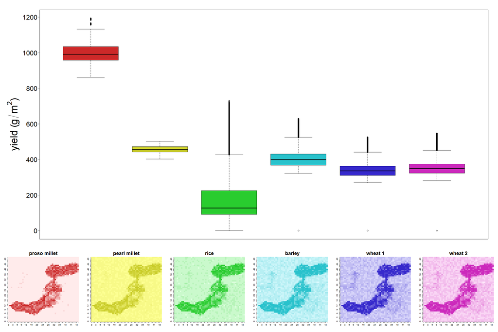

```r
knitr::include_graphics(plotName)
```

Alternative using `heatmap`: NOTE: this function is incompatible with `layout` so plots must be generated separately; it is also hard to customise because of many inaccessible defaults which are set for biostatistics (i.e. genetic data, with lateral dendrograms)).

```r
for (aCrop in levels(cropTable$crop))
{
  plotName = paste0("plots/I2/meanYieldRaster_terrainRandomSeed=", terrainRandomSeed,"_", aCrop, ".png")

  grScale = 2

  png(plotName, width = grScale * 500, height = grScale * 300)

  par(mar = c(3,1,10,1), cex.main = grScale)
  heatmap(meanYield_byPosAndCrop[[aCrop]],
        Rowv = NA, Colv = NA,
        main = aCrop,
        labRow = minY:maxY, labCol = minX:maxX,
        cexRow = 0.8 * grScale, cexCol = 0.8 * grScale)

  dev.off()
}
```

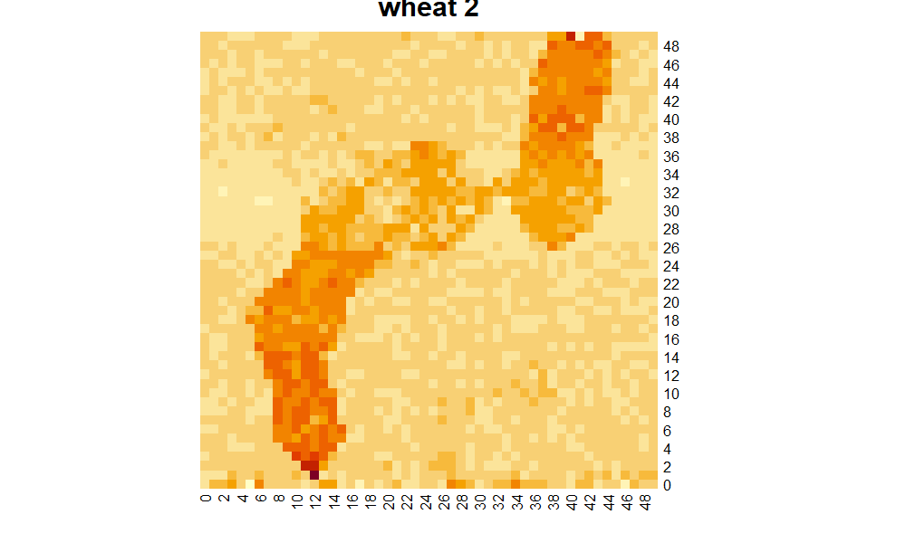

```r
knitr::include_graphics(plotName)
```